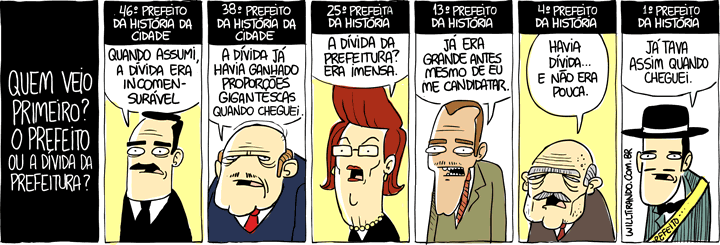

Créditos da imagem: [William Leite](http://www.willtirando.com.br/)

# Dívidas pra que te quero

As dívidas de Estados, Municípios e União

Dívida é uma quantia que se tem de pagar a alguém. O que interessa bastante para esse alguém. E muito importante para quem deve. Caso você não seja nenhum dos dois, por que continuar lendo sobre esse assunto?

Bom, vivemos em uma cidade, que tem uma prefeitura, certo? Essa cidade está dentro de um estado, que tem um governo. E isso tudo (incluindo você) fica em um país. Você teria curiosidade em saber o quanto eles declaram que devem?

Ao longo do texto, existem vários termos destacados com o fundo azul. Para não interromper a narrativa com tecnicismos, os conceitos envolvidos estão descritos de forma mais precisa e rigorosa em quadros que podem ser exibidos (e ocultados) clicando-se sobre esses termos com fundo em azul.

Origem e Abrangência das informações

A principal fonte de dados deste painel é o Sistema de Informações Contábeis e Fiscais do Setor Público Brasileiro - SICONFI, em especial, os dados declarados pelos entes federativos através dos Relatórios de Gestão Fiscal - RGF.

As informações sobre os encargos e condições de contratação dos estados e municípios. por sua vez, estão disponíveis no módulo de Cadastro da Dívida Pública (CDP) do Sistema de Análise da Dívida Pública, Operações de Crédito e Garantias da União, Estados e Municípios (SADIPEM). O CDP recebe a declaração detalhada das dívidas dos estados e municípios. Atualmente, nem todos os estados e municípios enviam essa declaração, o que pode causar divergência nos dados.

O Tesouro Nacional vem trabalhando para melhorar a qualidade e para aumentar a disponibilidade dessas informações para que a sociedade brasileira possa ter uma visão ampla sobre estoque e composição das dívidas dos entes, dois indicadores importantes de sua saúde financeira. Esse esforço passa, principalmente, pela ampliação do uso dos dados do SICONFI e pela melhoria de sua coleta, por meio da Matriz de Saldos Contábeis.

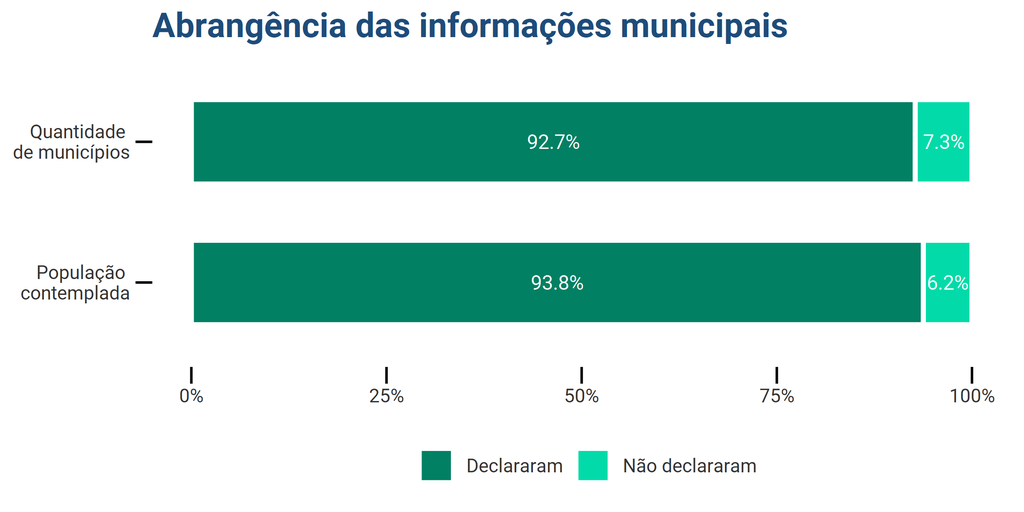

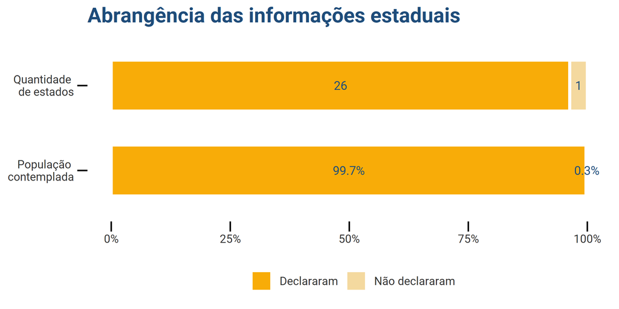

Os dados são referentes ao dia 31 de dezembro do exercício anterior.

^ Fechar e voltar ao texto ^

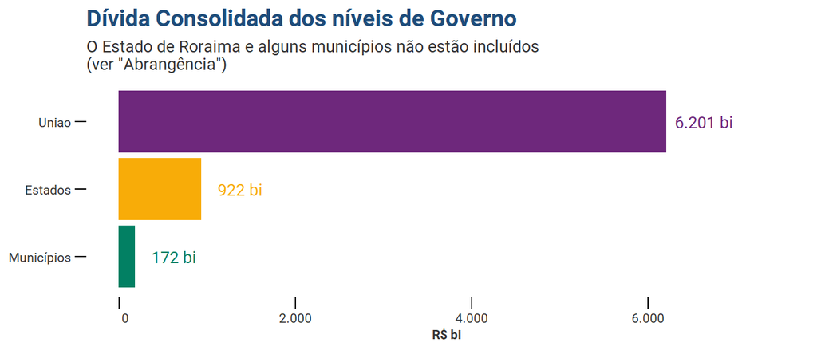

Veja o valor da dívida consolidada do estado e/ou do município em que você mora. Pode-se dizer que está grande ou pequena?

[interactive chart not shown]

Difícil responder olhando só para os números, não é? O ideal seria buscar referências de comparação.

Antes disso, porém, é preciso garantir que estamos falando de coisas iguais. No caso da dívida consolidada, entram, essencialmente, a dívida mobiliária, quando o país emite títulos públicos para captar dinheiro; a dívida contratual, quando os governos estaduais e municipais recorrem a empréstimos e (re)financiamentos, inclusive com o próprio governo federal; e a dívida de precatórios que venceram e não foram pagos, aquelas impostas por ações judiciais.

Dívida Consolidada e as várias formas de se medir a dívida pública

Na verdade, existem diversas formas de se medir a dívida de um ente público. É possível que você já tenha esbarrado em alguns desses: DPF, DPMFi, DBGG, DLSP, DC… uma verdadeira sopa de letrinhas.

A Dívida Consolidada ou Fundada* corresponde ao montante total das obrigações financeiras, apurado sem duplicidade (excluídas obrigações entre órgãos da administração direta e entre estes e as entidades da administração indireta), assumidas:

1. pela emissão de títulos públicos, para amortização em prazo superior a 12 (doze) meses (dívida mobiliária);
2. em virtude de leis, contratos (dívida contratual), convênios ou tratados e da realização de operações de crédito**, para amortização em prazo superior a 12 (doze) meses;
3. pela realização de operações de crédito que, embora de prazo inferior a 12 (doze) meses, tenham constado como receitas no orçamento;
4. com os precatórios judiciais emitidos a partir de 5 de maio de 2000 e não pagos durante a execução do orçamento em que houverem sido incluídos;
5. pela realização de operações equiparadas a operações de crédito pela LRF, para amortização em prazo superior a 12 (doze) meses.

* Esse conceito de dívida pública consolidada ou fundada, definido no art. 29, I, da Lei de Responsabilidade Fiscal, difere da classificação patrimonial da dívida adotada pelo art. 98 da Lei nº 4.320/64. Apesar de a Lei nº 4.320/64 também usar o termo dívida fundada e a LRF tratar como sinônimas as expressões dívida pública consolidada ou fundada, entende-se que o conceito apresentado na LRF é mais amplo que o inscrito Lei nº 4.320/64. A LRF conferiu maior abrangência à definição do que integra a dívida pública consolidada ou fundada para os seus fins, buscando dar transparência à natureza e ao volume do endividamento dos entes públicos.

** Operações de crédito são compromissos financeiros assumidos em razão de mútuo, abertura de crédito, emissão e aceite de título, aquisição financiada de bens, recebimento antecipado de valores provenientes da venda a termo de bens e serviços, arrendamento mercantil e outras operações assemelhadas, inclusive com o uso de derivativos financeiros. Equipara-se à operação de crédito a assunção, o reconhecimento ou a confissão de dívidas pelo ente da Federação. Dados detalhados das operações de crédito dos estados e municípios (incluindo encargos e condições contratuais) podem ser obtidos SADIPEM/CDP.

^ Fechar e voltar ao texto ^

PRECA-o quê??

Referem-se aos precatórios judiciais emitidos a partir de 5 de maio de 2000 e não pagos durante a execução do orçamento em que houverem sido incluídos. Os precatórios emitidos a partir de 5 de maio de 2000 devem ser pagos até o dia 31 de dezembro do exercício em que foram incluídos no orçamento. Caso o pagamento não seja efetuado até essa data limite, o valor correspondente deverá compor a dívida do ente até que o pagamento seja realizado. A diferenciação entre precatórios judiciais emitidos antes e após 5 de maio de 2000 foi feita pela própria LRF, ao definir o montante de precatórios do ente federativo que deveria ser considerado dívida consolidada para fins fiscais. Essa regra conjuga-se com o disposto na Constituição Federal, que estabelece ser obrigatória a inclusão, no orçamento das entidades de direito público, de verba necessária ao pagamento de seus débitos, oriundos de sentenças transitadas em julgado, constantes de precatórios judiciários apresentados até 1º de julho, efetuando-se o pagamento até o final do exercício seguinte.

^ Fechar e voltar ao texto ^

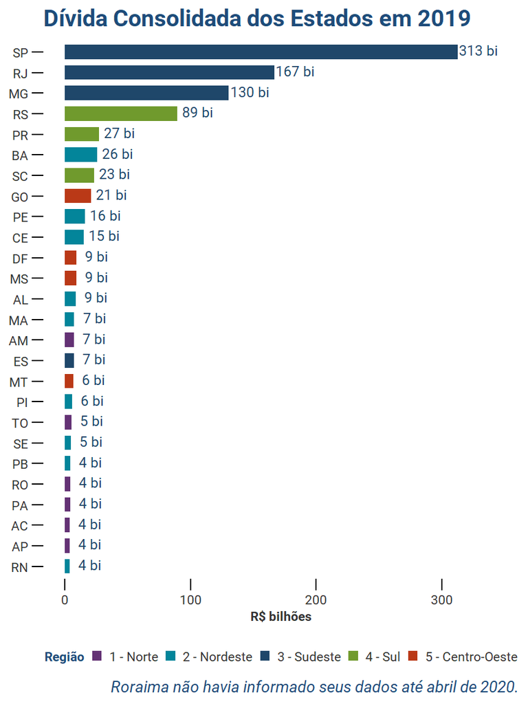

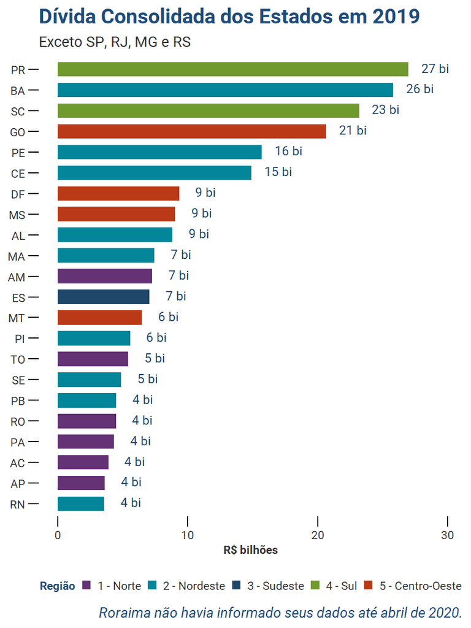

Após garantir que todos colocam os mesmos tipos de dívidas na dívida consolidada, voltamos à pergunta: a dívida está grande ou pequena? Como comparar?

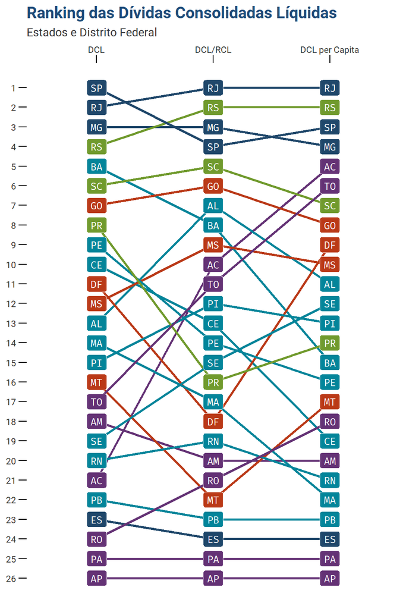

Essa avaliação depende da condição financeira de cada um para pagar a dívida. Assim, uma comparação com a arrecadação da prefeitura ou do governo pode ajudar nessa resposta.

Uma opção seria ver quanto sobra da dívida consolidada depois de abater os recursos que já estão em caixa. Isso recebe o nome de dívida consolidada L-Í-Q-U-I-D-A.

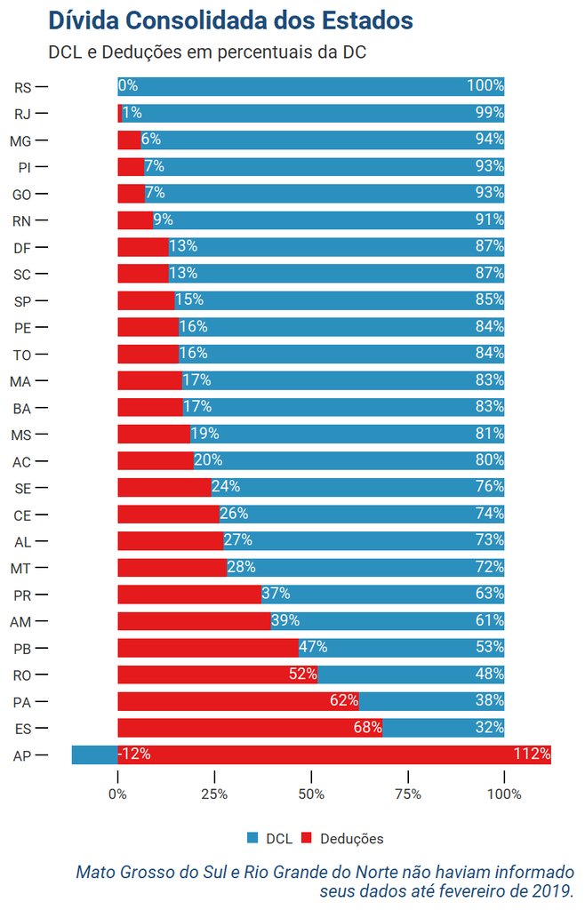

E se compararmos esse valor com algo que reflita uma capacidade de arrecadação? Podia ser o total de receitas regulares disponíveis, a RECEITA CORRENTE L-Í-Q-U-I-D-A, dos últimos 12 meses. Essa opção agrada a você? Saiba que essa foi a medida adotada pelo Senado Federal para estabelecer um limite para estados e municípios. Limite?

Receita Corrente Líquida

A Receita Corrente Líquida - RCL é o somatório das receitas correntes, ou seja, receitas de impostos, taxas e contribuições de melhoria, de contribuições, patrimoniais, agropecuárias, industriais, de serviços, transferências correntes e outras receitas correntes do ente da Federação, deduzidos alguns itens explicitados pela própria LRF. As deduções mais relevantes são as repartições de receitas tributárias previstas na constituição e as contribuições dos servidores aos regimes de previdência.

A RCL serve de parâmetro para os limites da despesa total com pessoal, da Dívida Consolidada Líquida, das operações de crédito, do serviço da dívida e para a concessão de garantias.

^ Fechar e voltar ao texto ^

Sim, a dívida consolidada líquida dos estados não pode ser duas vezes maior que a sua receita corrente líquida. Ou seja, se o estado não tivesse nenhuma outra despesa, precisaria de 2 anos de arrecadação para pagar essa dívida. Já a dos municípios não pode superar 1,2 vezes ou 1 ano e quase 3 meses de arrecadação. Parece razoável? A cidade e o estado em que você mora estão abaixo ou acima do limite?

Limites de Endividamento

Os limites da dívida consolidada foram estabelecidos por Resoluções do Senado Federal em termos da Dívida Consolidada Líquida, que corresponde à Dívida Consolidada ou Fundada deduzidas as disponibilidades de caixa e demais haveres financeiros. Seguem os limites de endividamento por esfera:

1. O limite de endividamento definido para os estados é de 200% da RCL.
2. O limite de endividamento definido para os municípios é de 120% da RCL.
3. Para a União, esse limite ainda não foi definido.

^ Fechar e voltar ao texto ^

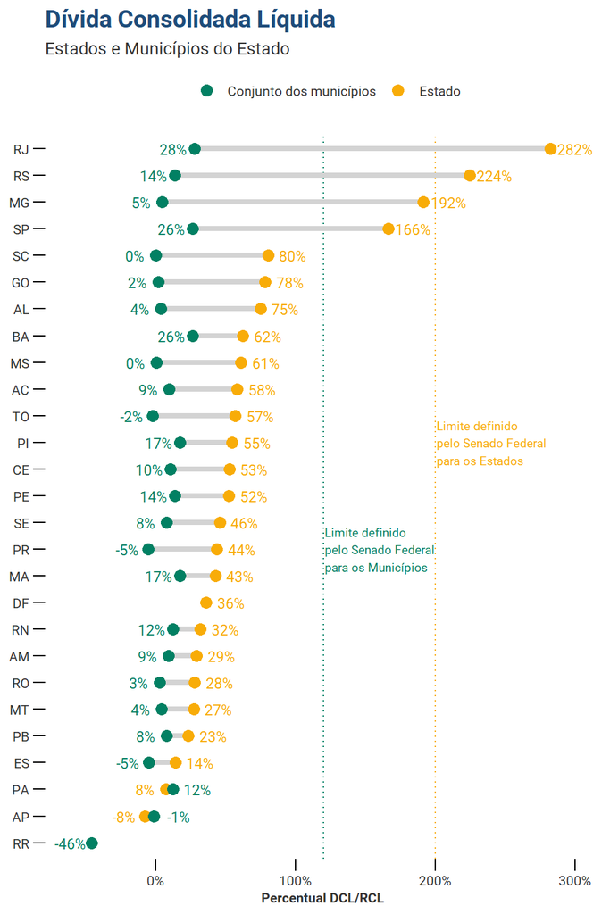

Aqui, o percentual da relação DCL/RCL de cada estado é comparado com o percentual da relação DCL/RCL de todos os municípios (na verdade, todos os que apresentaram seus relatórios) do estado. Ou seja, o índice dos municípios é calculado pela soma de todas as DCLs dos municípios do estado, dividida pela soma de todas as RCLs desses municípios.

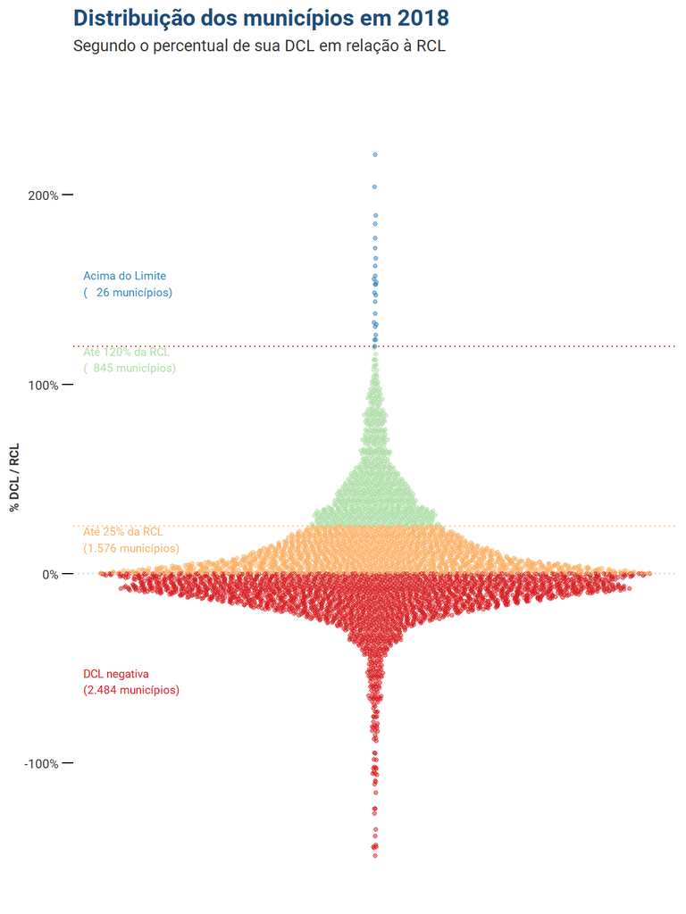

Cada município é representado por um ponto no gráfico acima, e sua posição vertical e sua cor correspondem ao valor da relação entre sua Dívida Consolidada Líquida e sua Receita Corrente Líquida. Assim, quanto mais pra cima no gráfico, maior a relação Dívida/Receita do município – lembrando que o limite máximo para essa relação é de 120%, segundo o Senado. Mas veja que não são muitos os municípios que estão ultrapassando esse limite.

Agora, uma pergunta: toda dívida entra no cálculo da dívida consolidada? Para onde vão os precatórios que não estão vencidos, por acaso?

O fato de não contar para a dívida consolidada não significa que não sejam relevantes, muito menos que não mereçam nossa atenção. É o caso, por exemplo, da obrigação com os pagamentos futuros de benefícios previdenciários, conhecido como passivo atuarial. Apesar de não afetar a capacidade financeira hoje, irá impactar nos próximos anos. Outro tipo ocorre quando a prefeitura ou o governo utiliza recursos que ainda estão em disputa judicial. Se perder a disputa, tem que devolver e isso precisa ser monitorado. Entendeu a importância?

Passivo Atuarial

O Passivo Atuarial dos Regimes Próprios de Previdência Social - RPPS (Provisão Matemática Previdenciária) representa o total dos recursos necessários ao pagamento dos compromissos dos planos de benefícios, calculados atuarialmente, em determinada data, a valor presente, conforme parecer atuarial mais recente.

^ Fechar e voltar ao texto ^

Disputa Judicial

Os depósitos judiciais são valores depositados em contas específicas sob a guarda do poder judiciário para pagamento de lides ainda pendentes de decisão judicial. A Constituição Federal autoriza a utilização de parte desses depósitos pelos entes da federação, os quais devem ser devolvidos caso o ente não seja favorecido pela decisão judicial.

^ Fechar e voltar ao texto ^

Por outro lado, existem disputas judiciais que já foram perdidas e exigem pagamento, são os precatórios. Pela quantidade, eles entram em uma fila para serem quitados a cada ano. Isto é, **todo ano a prefeitura ou o governo tem que pagar um certo número de precatórios. Quando deveria pagar em um ano e não paga, temos os precatórios vencidos e não pagos**. Lembra deles? Eles entram na dívida consolidada. Perceba que, por uma questão de tempo, os outros não entram nesse cálculo, mas estão na fila e vão afetar as finanças dessa prefeitura ou desse governo. Por isso, que tal ver o tamanho da conta de precatórios?

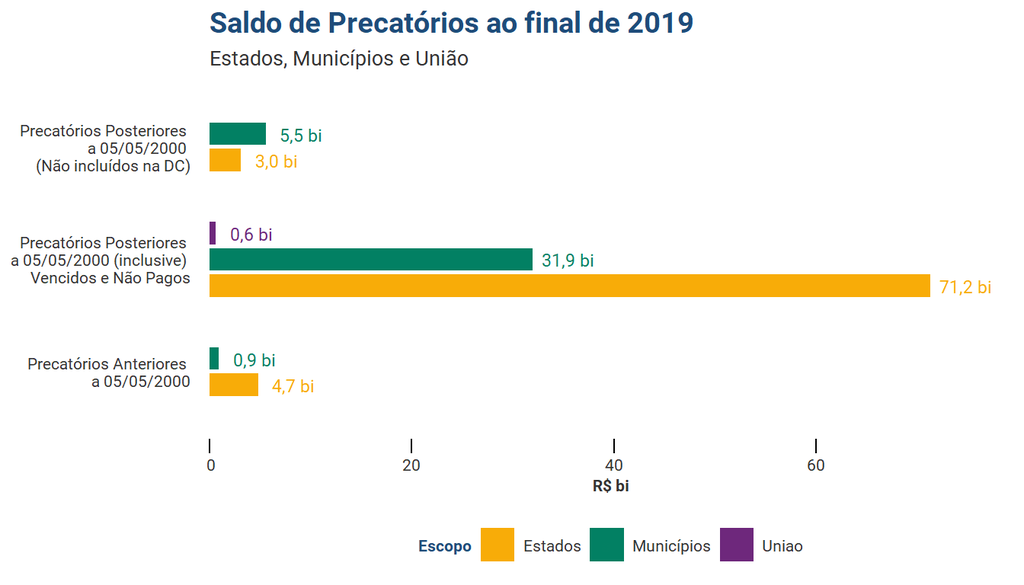

Além dessas obrigações, um compromisso também pode causar preocupação a uma prefeitura ou a um governo. E que tipo de compromisso seria esse? Aquele que pode virar uma dívida. Explicando melhor: algumas vezes uma prefeitura ou um governo entra como garantidor de um empréstimo. Essa garantia concedida pode se transformar em dívida se quem pegou o dinheiro emprestado não conseguir pagar. Viu como esse ponto é sensível? Por via das dúvidas, melhor acompanhar essas garantias.

Garantias Concedidas

Garantia é o compromisso de adimplência de obrigação financeira ou contratual assumida pelo ente da Federação por ocasião da realização de operações de crédito por suas estatais não dependentes ou por outros entes da federação.

Para a concessão de garantias, a LRF determina que sejam exigidas contragarantias, que são contrapartidas oferecidas pelo ente federativo que irá receber uma garantia. Essa contragarantia deve ser em valor igual ou superior ao da garantia a ser concedida para abranger o ressarcimento integral dos custos financeiros decorrentes da cobertura de eventual inadimplemento. Nesse caso, o ente entra como garantidor de uma dívida e, caso não seja honrada pelo tomador do empréstimo, o garantidor deverá honrar essa dívida.

^ Fechar e voltar ao texto ^

Relembrando, dívida é uma quantia que se tem de pagar a alguém.

Acrescentando: público é aquilo que pertence ao governo de um país, de um estado, de uma cidade. Também é aquilo que pertence a um povo, a uma coletividade.

(E o que seria dívida pública?)

Feito com dados, códigos e ♥ ♥ abertos.